# Google Capstone / Cyclistic bike-share

ADAM ZANUB

2023-11-08

# My Task :

The business task is to get clear and deep insights by finding out the answer to the main question we have :

**How do annual members and casual riders use Cyclistic bikes differently?**

# Data Source:

- I used Cyclistic’s historical trip data to analyze and identify trends.
- I downloaded the data from the following link: [URL data source](https://divvy-tripdata.s3.amazonaws.com/index.html)
- The data has been made available by Motivate International Inc. under this [license](https://www.divvybikes.com/data-license-agreement)
- The data were collected during the year 2023, for the first quarter of the year.

# install & load library

```r
library(tidyverse)
library(tidygeocoder)
library(lubridate)
library(hms)
library(ggrepel)
```

# Importing & combinning data

```r
jan <- read_csv("raw.csv")
feb <- read_csv("raw2.csv")
mar <- read_csv("raw3.csv")
bike_share <- rbind(jan, feb, mar)
```

# Exploration & preparation phase(1):

**performing the following assignments:**

1. Number of variables and observation that we have.
2. Check the names of each columns.
3. Understanding the structure of the dataset.
4. Discover the head and the tail of the data.
5. check out NA / missing values
6. Distinct values for each column
7. Duplicated data

```r
#initial explore
no_col_row <- dim(bike_share)

col_name <-colnames(bike_share)

structure_data <- glimpse(bike_share)
```

```
## Rows: 639,424
## Columns: 13
## $ ride_id            <chr> "F96D5A74A3E41399", "13CB7EB698CEDB88", "BD88A2E670…
## $ rideable_type      <chr> "electric_bike", "classic_bike", "electric_bike", "…
## $ started_at         <dttm> 2023-01-21 20:05:42, 2023-01-10 15:37:36, 2023-01-…
## $ ended_at           <dttm> 2023-01-21 20:16:33, 2023-01-10 15:46:05, 2023-01-…
## $ start_station_name <chr> "Lincoln Ave & Fullerton Ave", "Kimbark Ave & 53rd …
## $ start_station_id   <chr> "TA1309000058", "TA1309000037", "RP-005", "TA130900…
## $ end_station_name   <chr> "Hampden Ct & Diversey Ave", "Greenwood Ave & 47th …
## $ end_station_id     <chr> "202480.0", "TA1308000002", "599", "TA1308000002", …
## $ start_lat          <dbl> 41.92407, 41.79957, 42.00857, 41.79957, 41.79957, 4…
## $ start_lng          <dbl> -87.64628, -87.59475, -87.69048, -87.59475, -87.594…
## $ end_lat            <dbl> 41.93000, 41.80983, 42.03974, 41.80983, 41.80983, 4…
## $ end_lng            <dbl> -87.64000, -87.59938, -87.69941, -87.59938, -87.599…
## $ member_casual      <chr> "member", "member", "casual", "member", "member", "…
```

```r
head_data <- head(bike_share)

tail_data <- tail(bike_share)

total_na <- sum(is.na(bike_share))

locat_na <- colSums(is.na(bike_share))

get_duplicate <- janitor::get_dupes(bike_share)
```

```
## No variable names specified - using all columns.
```

```
## No duplicate combinations found of: ride_id, rideable_type, started_at, ended_at, start_station_name, start_station_id, end_station_name, end_station_id, start_lat, ... and 4 other variables
```

```r
# Unique values in each column
lapply( X=bike_share, FUN = n_distinct)
```

```
## $ride_id
## [1] 639424
##
## $rideable_type
## [1] 3
##
## $started_at
## [1] 594512
##
## $ended_at
## [1] 595322
##
## $start_station_name
## [1] 1103
##
## $start_station_id
## [1] 1067
##
## $end_station_name
## [1] 1121
##
## $end_station_id
## [1] 1083
##
## $start_lat
## [1] 196578
##
## $start_lng
## [1] 194605
##
## $end_lat
## [1] 973
##
## $end_lng
## [1] 962
##
## $member_casual
## [1] 2
```

**NOTE1:**

- The dataset has Rows: **639,424** and Columns: **13**
- Columns names are clean and readable
- The dataset has **363365** missing values distributed over six columns
- No duplicate combinations found

**Focus on each column individually:**

```r
# col 1:
id_data_type <- class(bike_share$ride_id)

check_id_char <-bike_share %>%
                  filter(nchar(ride_id)!= 16) %>%
                  print()
```

```
## # A tibble: 0 × 13
## # ℹ 13 variables: ride_id <chr>, rideable_type <chr>, started_at <dttm>,
## #   ended_at <dttm>, start_station_name <chr>, start_station_id <chr>,
## #   end_station_name <chr>, end_station_id <chr>, start_lat <dbl>,
## #   start_lng <dbl>, end_lat <dbl>, end_lng <dbl>, member_casual <chr>
```

**NOTE2:**

- There are no inconsistent values, every row has *16* characters
- Data has the same format e.g 6D6D09A15D92E4E6

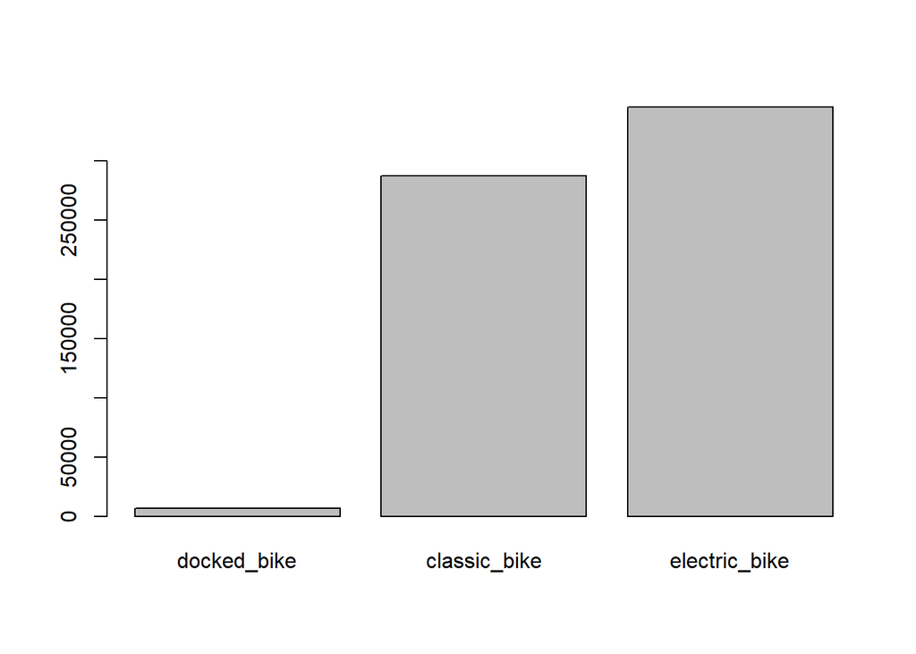

```r
# col 2:

bike_data_type <- class(bike_share$rideable_type)

unique_value_bike <- unique(bike_share$rideable_type)

no_unique_bike <- sort(
                    table(bike_share$rideable_type)
                      )
# initial data viz
sketch_viz_bike <- barplot(sort
                     (table(bike_share$rideable_type)
                     )
                          )
```

**NOTE3:**

- This column has three unique values.
- The data type in here is character, must be formatted as a **factor**.
- The docked bike is the least bike used by customers, while the electric bike is the most bikes are used.

```r
# col 3
start_time_type <- class(bike_share$started_at)

frequent_start_time <- View(sort
                             (table(bike_share$started_at)
                             )
                           )

# col 4
end_time_type <- class(bike_share$ended_at)


frequent_end_timeView <- (sort
                            (table(bike_share$ended_at)
                            )
                         )
```

**NOTE4:**

- The data type for both are **date**
- started time: (2023-03-30 17:06:48) frequent 5 times. There are other dates with the same recurring number, around *17 p.m*.
- ended time : (2023-03-22 17:30:49) frequent 11 times & (2023-03-21 16:59:40) frequent 10 times

```r
# col 5
unique_startstation <- view(unique
                         (bike_share$start_station_name)
                                )

no_unique_startstation <- print(length(unique
                         (bike_share$start_station_name)
                                ))
```

```
## [1] 1103
```

```r
total_na_startstation <- sum(
                       is.na(bike_share$start_station_name)
                            )

frequent_start_station <- View(sort
                                 (table
                           (bike_share$start_station_name)
                                 )
                              )
```

**NOTE5:**

- There’re **1103** unique values for the starting station names, and there’re **88104** missing values as well.
- The most frequent starting station is **University Ave & 57th St**

```r
# col 6
options(max.print = 100)  # Just to make report neat and readable

nochara_startstation_id <-  print(nchar(
                              bike_share$start_station_id
                                       )
                                 )
```

[output not shown]

```r
no_unique_startid <- print(length(str_unique
                       (bike_share$start_station_id)
                                 )
                           )
```

```
## [1] 1067
```

```r
total_na_startid <- print(sum(
                           is.na(bike_share$start_station_id)
                             )
                         )
```

```
## [1] 88236
```

**NOTE6:**

- There’re **1067** unique values, and the format of id start station names looks messy
- There’re **88236** missing values

```r
#col 7
unique_endstation <- view(unique
                             (bike_share$end_station_name)
                         )

no_unique_endstation <- print(length(unique
                         (bike_share$end_station_name)
                                    )
                              )
```

```
## [1] 1121
```

```r
total_na_endstation <- sum(
                      is.na(bike_share$end_station_name)
                          )

frequent_end_station <- View(sort
                                 (table
                           (bike_share$end_station_name)
                                 )
                             )
```

**NOTE7:**

- There’re **1121** unique values for the ending station names, and there’re **93016** missing values as well.
- The most frequent ending station is **University Ave & 57th St**

```r
#col 8
options(max.print = 100)  # Just to make report neat and readable

nochara_endstation_id <-  print(nchar(
                              bike_share$end_station_id
                                      )
                                )
```

[output not shown]

```r
no_unique_endid <- print(length(str_unique
                       (bike_share$end_station_id)
                               )
                        )
```

```
## [1] 1083
```

```r
total_na_endid <- print(sum(
                     is.na(bike_share$end_station_id)
                            )
                        )
```

```
## [1] 93157
```

**NOTE8:**

- There’re **1083** unique values, and the format of id end station names looks messy
- There’re **93157** missing values

```r
#col 9
strat_lat_type <- typeof(bike_share$start_lat)


frequent_strat_lat <- view(sort
                            (table(bike_share$start_lat)
                            )
                          )

total_na_startlatitude <- print(sum(
                            is.na(bike_share$start_lat)
                                   )
                               )
```

```
## [1] 0
```

```r
#col 10
strat_lng_type <- typeof(bike_share$start_lng)

frequent_strat_lng <- view(sort
                            (table(bike_share$start_lng)
                            )
                          )

total_na_startlongitude <- print(sum(
                                  is.na(bike_share$start_lng)
                                    )
                                )
```

```
## [1] 0
```

**NOTE9:**

- Both columns have the same data type which is **double**
- The most common start latitudes **[41.89] –> 11767** times
- The most common start longitudes **[-87.65] –> 15955** times

```r
#col 11
end_lat_type <- typeof(bike_share$end_lat)


frequent_end_lat <- view(sort
                            (table(bike_share$end_lat)
                            )
                        )

total_na_endlatitude <- print(sum(
                              is.na(bike_share$end_lat)
                                 )
                              )
```

```
## [1] 426
```

```r
#col 12

strat_lng_type <- typeof(bike_share$end_lng)

frequent_strat_lng <- view(sort
                            (table(bike_share$end_lng)
                            )
                          )

total_na_endlongitude <- print(sum(
                            is.na(bike_share$end_lng)
                                   )
                               )
```

```
## [1] 426
```

**NOTE10:**

- Both columns have the same data type which is **double**
- The most common end latitudes **[41.89] –> 12279** times
- The most common end longitudes **[-87.65] –> 16312** times
- In both columns there are 426 missing values

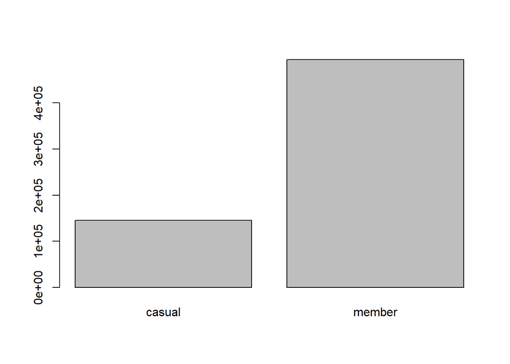

```r
# col 13

datatype_customer <- class(bike_share$member_casual)

unique_customer <- str_unique(bike_share$member_casual)

frequent_customer <- view(sort(table
                       (bike_share$member_casual)
                              )
                         )
#initial data viz
sketch_viz_customer <- barplot(sort
                          (table(bike_share$member_casual)
                          )
                              )
```

**NOTE11:**

- The data type is character, must be formatted as a *factor*.
- There are **145225** casual, and **494199** member.

# Cleaning & Processing Phase(2):

**First I need to make sure of two essential things**

- Emphasize that there are no duplicate values.
- Locate missing values

```r
dup_data <- bike_share[duplicated(bike_share), ]
print(dup_data)
```

```
## # A tibble: 0 × 13
## # ℹ 13 variables: ride_id <chr>, rideable_type <chr>, started_at <dttm>,
## #   ended_at <dttm>, start_station_name <chr>, start_station_id <chr>,
## #   end_station_name <chr>, end_station_id <chr>, start_lat <dbl>,
## #   start_lng <dbl>, end_lat <dbl>, end_lng <dbl>, member_casual <chr>
```

```r
pinpoint_na_values <- print(names(
                  which(
                      colSums(is.na(bike_share)) > 0
                       )
                                 )
                           )
```

```
## [1] "start_station_name" "start_station_id"   "end_station_name"
## [4] "end_station_id"     "end_lat"            "end_lng"
```

**Col 2 & 13 Converting data type to factor:**

```r
# col 2
bike_share$rideable_type <- as.factor(bike_share$rideable_type)
class(bike_share$rideable_type)
```

```
## [1] "factor"
```

```r
# col 13
bike_share$member_casual <- as.factor(bike_share$member_casual)
class(bike_share$member_casual)
```

```
## [1] "factor"
```

**filter to take a look why there’re NAs**

```r
# start station

# Creating  a dataframe which include missing values with two columns (latitude &longitude)
missing_value_start <- bike_share %>%
                          select(start_station_name, start_station_id,
                                       start_lat,start_lng) %>%
                           filter(is.na(start_station_name)
                                 ) %>%
                           mutate(
                    nochar_lat=nchar(start_lat),
                    nochar_lng=nchar(start_lng)
                                 )

# Check out decimal places in latitude and longitude
checK_lat_start <- missing_value_start[missing_value_start$nochar_lat > 5
                                  |missing_value_start$nochar_lat < 2, ]

check_lng_start <- missing_value_start[missing_value_start$nochar_lng > 6
                                  |missing_value_start$nochar_lng < 5, ]
```

**NOTE1**

- In both columns *start station name & start station id* there are *88104* NAs
- for latitude the range of decimal places –> [0, 2]
- for longitude the range of decimal places –> [1,2]

```r
# end station
# creating the same previous dataframe  for end station
missing_value_end <- bike_share %>%
                        select(end_station_name, end_station_id,
                               end_lat,end_lng) %>%
                        filter(is.na(end_station_name)
                               ) %>%
                        mutate(
                        nochar_lat=nchar(end_lat),
                        nochar_lng=nchar(end_lng)
                              )

# Check out decimal places in latitude and longitude
checK_lat_end <- missing_value_end[missing_value_end$nochar_lat > 5
                                    |missing_value_end$nochar_lat < 2, ]

check_lng_end <- missing_value_end[missing_value_end$nochar_lng>6
                                    |missing_value_end$nochar_lng < 5, ]
```

**NOTE2**

- In both columns **end station name & end station id** there are **93016** NAs
- For latitude the range of decimal places –> [0, 2]
- For longitude the range of decimal places –> [1,2]
- Through *checK_lat_end & check_lng_end* I have revealed a total of 426 missing values completely. Station and coordinate information are completely missing.
- We need coordinates out to at least five (5) decimal places to be usable in terms of locating, However, in this data we only have (2) decimal places at the best. It may be caused by the company’s GPS system failing which resulted in the inability to determine the station name and station ID.

**Extracting the address for each start_station_name & end_station_name based on lat/lng**

- I’ve created the project from version control for this purpose:

Clona Git repository *—>* The link that I used [URL repository](https://github.com/business-science/free_r_tips)

```r
# table contains  NA in both columns start&end
miss_stname <- bike_share[is.na
                          (bike_share$start_station_name), ]

# divide this table into two tables:

# A table contains the corresponding missing values in each of the start and end station names

miss_st_end <- miss_stname[is.na(miss_stname$end_station_name) &
            is.na(miss_stname$start_station_name),
                          ]

# reverse_geocode
miss_st_end <- miss_st_end %>%
    reverse_geocode(
        lat = start_lat,
        long = start_lng,
        method = "osm"
    )
```

```
## Passing 516 coordinates to the Nominatim single coordinate geocoder
```

```
## Query completed in: 528.8 seconds
```

```r
#transfer values from col[address] to col [start_station_name]
miss_st_end["start_station_name"] <- miss_st_end["address"]


# delete col[address]
miss_st_end <- miss_st_end[,-14]

# Extract only street name
miss_st_end  <- miss_st_end %>%
    separate(col =start_station_name,
             into=c("street1","street2"),
             sep= ",") %>%
    unite(col = "start_station_name",
          street1, street2,  sep="")

# table contains NA only in start_station name
miss_startstation <- miss_stname[
                           !is.na(miss_stname$end_station_name),
                                ]

# reverse_geocode
miss_startstation <- miss_startstation %>%
    reverse_geocode(
        lat = start_lat,
        long = start_lng,
        method = "osm"
                    )
```

```
## Passing 491 coordinates to the Nominatim single coordinate geocoder
```

```
## Query completed in: 505.2 seconds
```

```r
#transfer values from col[address] to col [start_station_name]

miss_startstation["start_station_name"] <-
                                miss_startstation["address"]

# delete col 14
miss_startstation <- miss_startstation[,-14]

# Extract only street name
miss_startstation  <- miss_startstation %>%
    separate(col = start_station_name,
                    into=c("street1","street2"),
                     sep= ",") %>%
    unite(col = "start_station_name", street1, street2, sep="")
```

```r
#table contains NA only in end_station name
miss_endstation <- bike_share[is.na(bike_share$end_station_name)&
                              !is.na(bike_share$start_station_name),
                              ]

# reverse_geocode
miss_endstation <- miss_endstation %>%
    reverse_geocode(
        lat = end_lat,
        long = end_lng,
        method = "osm"
                    )
```

```
## Passing 574 coordinates to the Nominatim single coordinate geocoder
```

```
## Query completed in: 585.3 seconds
```

```r
# transfer values from col[address] to col [end_station_name]

miss_endstation["end_station_name"] <- miss_endstation["address"]

# delete col 14
miss_endstation <- miss_endstation[,-14]

# Extract only street name
miss_endstation  <- miss_endstation %>%
    separate(col = end_station_name,
               into=c("street1","street2"),
                 sep= ",") %>%
    unite(col = "end_station_name", street1, street2,  sep="")


# A table contains the corresponding missing values in each of the start and end station names

# reverse_geocode
miss_st_end <- miss_st_end %>%
    reverse_geocode(
        lat = end_lat,
        long = end_lng,
        method = "osm"
                    )
```

```
## Passing 565 coordinates to the Nominatim single coordinate geocoder
```

```
## Query completed in: 576.6 seconds
```

```r
#transfer values from col[address] to col [end_station_name]
miss_st_end["end_station_name"] <- miss_st_end["address"]

# delete col 14
miss_st_end <- miss_st_end[,-14]

# Extract only street name
miss_st_end  <- miss_st_end %>%
    separate(col = end_station_name,
               into=c("street1","street2"),
                 sep= ",") %>%
    unite(col = "end_station_name", street1, street2,  sep="")
```

```r
# table without NA values
cyclist <- bike_share[!is.na(bike_share$start_station_name)&
                      !is.na(bike_share$end_station_name), ]

# Combine all table we made:

bike_share1 <- rbind(cyclist, miss_endstation, miss_startstation,
                     miss_st_end)
```

**Duration of rides**

```r
# calculating ride time

bike_share1$ride_time <- difftime(bike_share1$ended_at,
                                  bike_share1$started_at,
                                  units = "min")

# check if there any inconsistent value in ride_time column
check_time <- bike_share1[bike_share1[14] < 0, ]

# there's only one obs looks inconsistent , It has the same date but, start_at more than ended at ,and that does-not make sense

# delete the previous rows
bike_share1 <- subset(bike_share1, ride_id != "4EFC95304E050AA1")

# round off duration of trip:

bike_share1$ride_time <- as.double(bike_share1$ride_time)

bike_share1$trip_duration_min <- round(bike_share1$ride_time)

bike_share1 <- bike_share1[ ,-14]
```

**Summarize trip duration:**

```r
bike_share1 %>%
    group_by(member_casual) %>%
    summarize(max_duration = max(trip_duration_min),
               ave_duration = mean(trip_duration_min),
                min_duration= min(trip_duration_min))
```

```
## # A tibble: 2 × 4
##   member_casual max_duration ave_duration min_duration
##   <fct>                <dbl>        <dbl>        <dbl>
## 1 casual               33604         22.4            0
## 2 member                1560         10.5            0
```

**NOTE3:**

- The casual customer has the biggest average comparison to the member customers.Nevertheless members format the biggest portion

```r
#  max duration (casual)
bike_share1 %>%
    filter(trip_duration_min == 33604) %>%
    View()

#  max duration (member)
bike_share1 %>%
    filter(trip_duration_min == 1560) %>%
    View()
```

**NOTE4:**

- casual max duration equal to **33604 minutes** it’s a unique value while member max duration equal to **1560 minutes** and there are multiple value though. However, all these max values include missing values at end station name, end lat, end lng.

```r
#the remaining NAs, which equals 426
missing_values <- bike_share1 %>%
    arrange(member_casual) %>%
    select(-ride_id, -start_station_id, -end_station_id) %>%
    filter(is.na(end_lat), is.na(end_lng))

# for casual
missing_values_casual <- missing_values %>%
    select(member_casual, trip_duration_min) %>%
    filter(member_casual == "casual")

# the range of duration
range(missing_values_casual$trip_duration_min, na.rm=TRUE)
```

```
## [1]     2 33604
```

```r
# for member
missing_values_member <- missing_values %>%
    select(member_casual, trip_duration_min) %>%
    filter(member_casual == "member")

# the range of duration
range(missing_values_member$trip_duration_min, na.rm = TRUE)
```

```
## [1] 1500 1560
```

**NOTE5:**

1. member trip_duration_min range [1500 - 1560]
2. casual trip_duration_min range [2 - 33604]
3. I noticed that end_station_name with end_lat & end_lng in this piece of data has the biggest number of ride length and the casual customer takes the biggest proportion.
4. There’s something wrong: end_station_name, latitude , longitude all of them are missing
- I believe that’s in this piece of data the bicycles might have been stolen or been involved in an accident which resulted in not registered on the system so I decided to delete this piece of data for two reasons : that’s not a huge number and there is also doubt about accuracy of this data

```r
# delete 426 NAs
bike_share1 <- subset(bike_share1, !is.na(end_lng) )
```

```r
# check out how the dataframe changed after deleting the missing values

duration_summary <- bike_share1 %>%
            group_by(member_casual) %>%
            summarize(max_duration = max(trip_duration_min),
                 ave_duration = mean(trip_duration_min),
                 min_duration= min(trip_duration_min)
                 )
```

```r
# summarize based on bike type and customer type

duration_summary1 <- bike_share1 %>%
    group_by(member_casual, rideable_type) %>%
     summarise(max_duration = max(trip_duration_min),
              ave_duration = mean(trip_duration_min),
              min_duration= min(trip_duration_min))
```

**NOTE6:**

```r
# the most common durations within casual are :
common_dura_casual <- bike_share1 %>%
         filter(member_casual == "casual") %>%
         count(trip_duration_min)


# the common duration within member :
common_dura_member <- bike_share1 %>%
    filter(member_casual == "member") %>%
    count(trip_duration_min)

# total all duration
all_duration <- sum(bike_share1$trip_duration_min)

# Duration of trips made by each type of customer throughout 3 months
total_duration <- bike_share1 %>%
    select(member_casual, trip_duration_min) %>%
    group_by(member_casual) %>%
    summarise(
        sum(trip_duration_min)
        )

casual_duration1 <- 2168512

member_duration2 <- 5070809
```

**NOTE7**

- The common duration within *casual* customer: *1st:* 5 min , *2nd:* 4 min , *3rd:* 6 min, *4th:* 7min, *5th:* 8min
- The common duration within *member* customer: *1st:* 4 min , *2nd:* 5 min , *3rd:* 6 min, *4th:* 3min, *5th:* 7min
- Total duration equal to 7,239,321 minutes (casual = 2,168,512) & (member = 5,070,809)

*Times of ride*

```r
# Extracting time from date
# for started
bike_share1$started_time <- format(
                   as.POSIXct(bike_share1$started_at),
                                                "%H:%M:%S")
class(bike_share1$started_time)
```

```
## [1] "character"
```

```r
#convert character to hms time data type
bike_share1$started_time <- as_hms(bike_share1$started_time)

# for ended
bike_share1$ended_time <- format(
                   as.POSIXct(bike_share1$ended_at),
                                                 "%H:%M:%S")
class(bike_share1$ended_time)
```

```
## [1] "character"
```

```r
#convert character to hms time data type
bike_share1$ended_time <- as_hms(bike_share1$ended_time)

# most and less start time frequent
common_start_time <- names(
                         which.max(
                           table(bike_share1$started_time)
                                  )
                          )

uncommon_start_time <- names(
                         which.min(
                           table(bike_share1$started_time)
                                   )
                            )
# most and less end end time frequent
common_end_time <- names(
                    which.max(
                          table(bike_share1$ended_time)
                             )
                         )

uncommon_end_time <- names(
                        which.min(
                          table(bike_share1$ended_time)
                                  )
                           )

# Common times used by cyclists
start_time_frequent <-sort(table(bike_share1$started_time),
                           decreasing = TRUE)[1:1000] %>%
                           View()

end_time_frequent <- sort(table(bike_share1$ended_time),
                          decreasing = TRUE)[1:1000] %>%
                          View()
```

**NOTE8**

- In the previous chunk of the code, I observed customer behavior depending on the duration of trips
- The busiest time is between **15 - 17:30 P.M.**

```r
# Create column for started day
bike_share1$started_day <- weekdays(
                              as.Date(bike_share1$started_at))

# create column for ended day
bike_share1$ended_day <- weekdays(
                              as.Date(bike_share1$ended_at))

#--started days --#

# check unique values   (for sure all days of week are exist)
confirm_start_days <- str_unique(bike_share1$started_day)

# most day frequent
common_start_day <- names(
                     which.max(
                           table(bike_share1$started_day)
                              )
                        )


# less day frequent
uncommon_start_day <- names(
                         which.min(
                              table(bike_share1$started_day)
                                  )
                            )
#--ended days--#

# check unique values
confirm_end_days <- str_unique(bike_share1$ended_day)

# most day frequent
common_end_day <- names(which.max
                            (table
                          (bike_share1$ended_day)
                            )
                        )
# less day frequent
uncommon_end_day <- names(which.min(
                          table(bike_share1$ended_day)
                                   )
                         )
```

**NOTE9:**

- The common day is **Tuesday**, while the uncommon day is **Saturday**.

*Study how each type of customer interacts with other variables we’re interested in*

```r
# create dataframe for casual
casual_data <- bike_share1 %>%
    select(member_casual,started_day, ended_day,started_time ,
           ended_time,trip_duration_min,rideable_type,
            start_station_name, end_station_name) %>%
    filter(member_casual == "casual")

# started_day
common_casual_startday <- names(
                            which.max(
                               table(casual_data$started_day)
                                     )
                                )

uncommon_casual_startday <- names(
                            which.min(
                              table(casual_data$started_day)
                                     )
                               )

# ended_day
common_casual_enday <- names(
                          which.max(
                            table(casual_data$ended_day)
                                   )
                            )

uncommon_casual_enday <- names(
                           which.min(
                            table(casual_data$ended_day)
                                    )
                               )

# busiest started days
busy_casual_startday  <- sort(
                          table(casual_data$started_day),
                                            decreasing = TRUE) %>%
                         View()

# busiest ended days
busy_casual_enday <- sort(
                       table(casual_data$ended_day),
                                         decreasing = TRUE) %>%
                     View()

# busiest started time
busy_casual_starttime  <- sort(
                            table(casual_data$started_time),
                                       decreasing = TRUE)[1:10] %>%
                          View()

# busiest ended time
busy_casual_endtime  <- sort(
                            table(casual_data$ended_time),
                                       decreasing = TRUE)[1:10] %>%
                           View()

# rideable_type
bike_type_casual <- sort(
                      table(casual_data$rideable_type),
                                      decreasing = TRUE) %>%
                    View()

# the top5 start streets casual customer used
top_startstreet_casual <- sort(
                            table(casual_data$start_station_name),
                                             decreasing = TRUE)[1:5] %>%
                          View()

#the top5 end streets casual customer used
top_endstreet_casual <- sort(
                          table(casual_data$end_station_name),
                                             decreasing = TRUE)[1:5] %>%
                        View()
```

**NOTE10:**

- The common day is **Sunday**, while the uncommon day is **Friday**
- The busiest time is between **14:30 - 17:30**
- Type of bike : **1st:** electric_bike 89373, **2nd:** classic_bike 48726, **3rd:** docked_bike 6777
- we got the top 5 for started streets, and the top 5 for ended streets as well. In both of them **Streeter Dr & Grand Ave**was the first place

```r
# create a dataframe for member
member_data <- bike_share1 %>%
    select(member_casual,started_day, ended_day,started_time ,
           ended_time,trip_duration_min,rideable_type,
           start_station_name, end_station_name) %>%
    filter(member_casual == "member")

# started_day
common_member_startday <- names(
                             which.max(
                                   table(member_data$started_day)
                                      )
                               )

uncommon_member_startday <- names(
                               which.min(
                                      table(member_data$started_day)
                                        )
                                 )

# ended_day
common_member_enday <- names(
                          which.max(
                            table(member_data$ended_day)
                                   )
                             )

uncommon_member_enday <- names(
                           which.min(
                             table(member_data$ended_day)
                                    )
                              )

# busiest started day
busy_member_startday <- sort(
                           table(member_data$started_day),
                                         decreasing = TRUE) %>%
                        View()

# busiest ended day
busy_member_enday <- sort(
                        table(member_data$ended_day),
                                         decreasing = TRUE) %>%
                        View()

# busiest started_time
busy_member_starttime  <- sort(
                            table(member_data$started_time),
                                           decreasing = TRUE)[1:5]

# busiest ended_time
busy_member_endtime  <- sort(
                            table(member_data$ended_time),
                                           decreasing = TRUE)[1:5]

# rideable_type
bike_type_member <- sort(
                       table(member_data$rideable_type),
                                          decreasing = TRUE) %>%
                    View()

# the top5 start streets member customer used
top_startstreet_member <- sort(
                            table(member_data$start_station_name),                                                       decreasing = TRUE)[1:5]

# The top5 end street member customer used
top_endstreet_member <- sort(
                         table(member_data$end_station_name),                                                         decreasing = TRUE)[1:5]
```

# Visualization Phase(3):

**The proportion of customers**

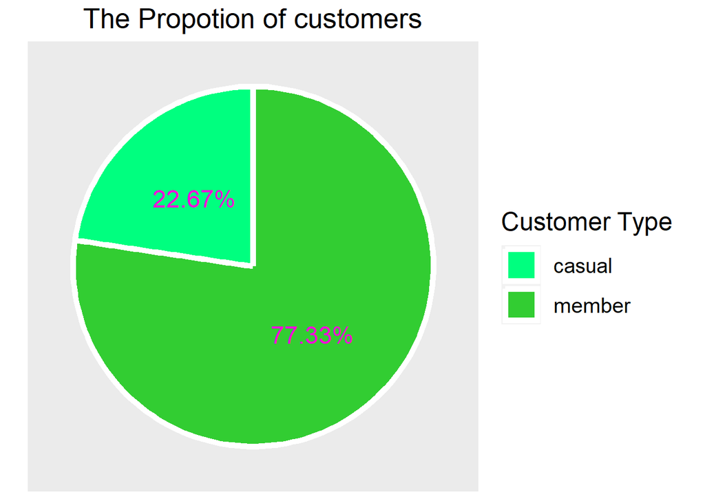

```r
# Create a data frame to help us visualize the data
total_customer <-bike_share1 %>%
                    count(member_casual)

total_customer <- total_customer %>%
                    rename(total_riders = n)

entire_no_customer <- 638997
multiply_by_ahundred <- 100

total_customer <- total_customer %>%
                        mutate(percentage_customer =
            total_riders/entire_no_customer*multiply_by_ahundred)

#rounding up to the second decimal point:
total_customer$percentage_customer <-
                round(total_customer$percentage_customer,digits = 2)

# Cumulative sums to spot the  texts on the plot in the right position
total_customer$running_total <-
                     cumsum(total_customer$percentage_customer) -
                                    0.5 * total_customer$percentage_customer

ylabel_position <- 100 - total_customer$running_total

# VIZ

pie_chart <- ggplot(total_customer, aes(x="", y=percentage_customer,
                                      fill=member_casual)) +
    geom_bar(stat="identity",linewidth=2, color = "white") +
    coord_polar("y", start= 0)

pie_chart+
    ggtitle("The Propotion of customers")+
    theme(plot.title = element_text(hjust = 0.5, size = 20),
          axis.title = element_blank(),
          axis.text = element_blank(),
          axis.ticks = element_blank(),
          panel.grid = element_blank(),
          panel.border = element_blank())+
    scale_fill_manual(values = c("#00ff7f", "#32cd32"),
                                      name = "Customer Type")+
    theme(legend.text = element_text(size = 15),
          legend.title = element_text(hjust = 0.5, size = 18),
          legend.key.size = unit(1, "cm"))+
    geom_text(aes(x = "", y = ylabel_position, label = paste0(percentage_customer, "%")
                  ), size = 6, color = "#fa00dc"
              )
```

**Type of bicycles**

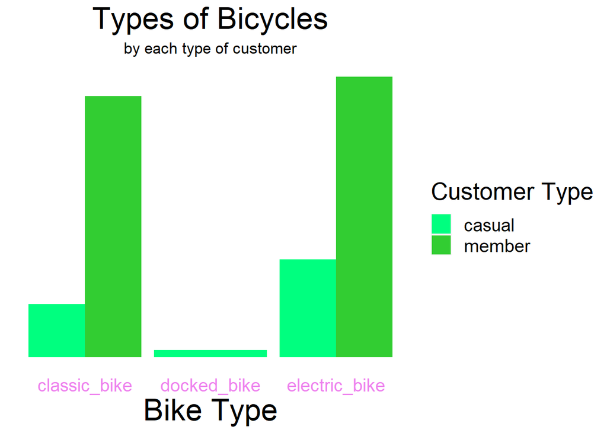

```r
bike_type <- ggplot(data = bike_share1)+
               geom_bar(mapping = aes(x= rideable_type ,fill = member_casual),
                                                                 position = "dodge")+
               scale_y_continuous(name="num_riders",
                                                labels = scales::comma)

bike_type+
    labs(title = "Types of Bicycles",
         subtitle = "by each type of customer", x = "Bike Type")+
    scale_fill_manual(values = c("#00ff7f", "#32cd32"),
                                         name = "Customer Type")+
    theme(plot.title = element_text(hjust = 0.5, size = 25),
          plot.subtitle = element_text(hjust = 0.5, size = 13),
          panel.background = element_blank(),
          axis.title.y = element_blank(),
          axis.text.y=element_blank(),
          axis.ticks.y=element_blank(),
          axis.text.x = element_text(size = 15, color = "violet"),
          axis.ticks.x = element_blank(),
          axis.title.x = element_text(size = 25),
          legend.title = element_text(size = 20),
          legend.text = element_text(size = 15))
```

**Analysis of rides duration**

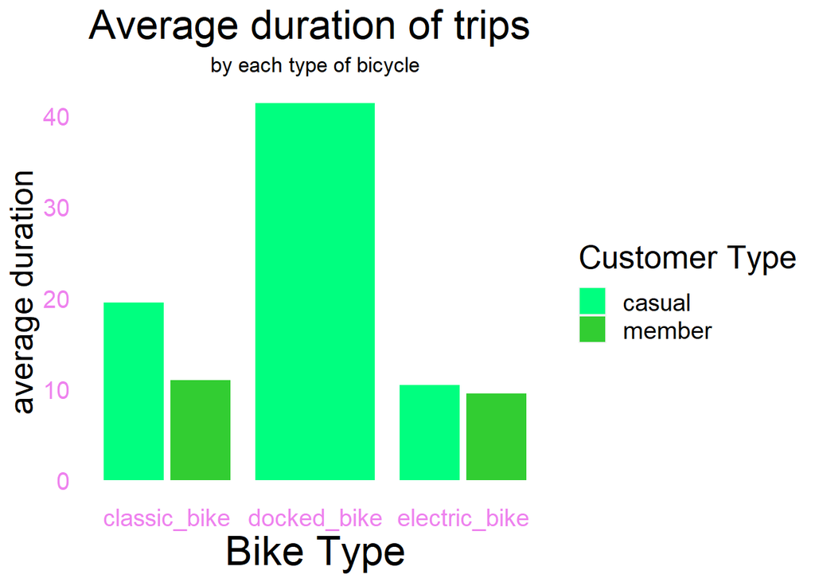

```r
#average duration of trips
summary_duration <- ggplot(duration_summary1,
                          aes(x = rideable_type,y = ave_duration,
                                                    fill = member_casual))+
                    geom_bar(stat = "identity",position = "dodge2")+
                    scale_fill_manual(values = c("#00ff7f", "#32cd32"),
                                                         name = "Customer Type")
summary_duration+
    labs(title = "Average duration of trips ",
         subtitle = "by each type of bicycle",
         x = "Bike Type", y = "average duration")+
    theme(plot.title = element_text(hjust = 0.5, size = 25),
          plot.subtitle = element_text(hjust = 0.5, size = 13),
          panel.background = element_blank(),
          axis.title.y = element_text(size = 20),
          axis.text.y= element_text(size = 15, color = "violet"),
          axis.ticks.y= element_blank(),
          axis.text.x = element_text(size = 15, color = "violet"),
          axis.ticks.x = element_blank(),
          axis.title.x = element_text(size = 25),
          legend.title = element_text(size = 20),
          legend.text = element_text(size = 15))
```

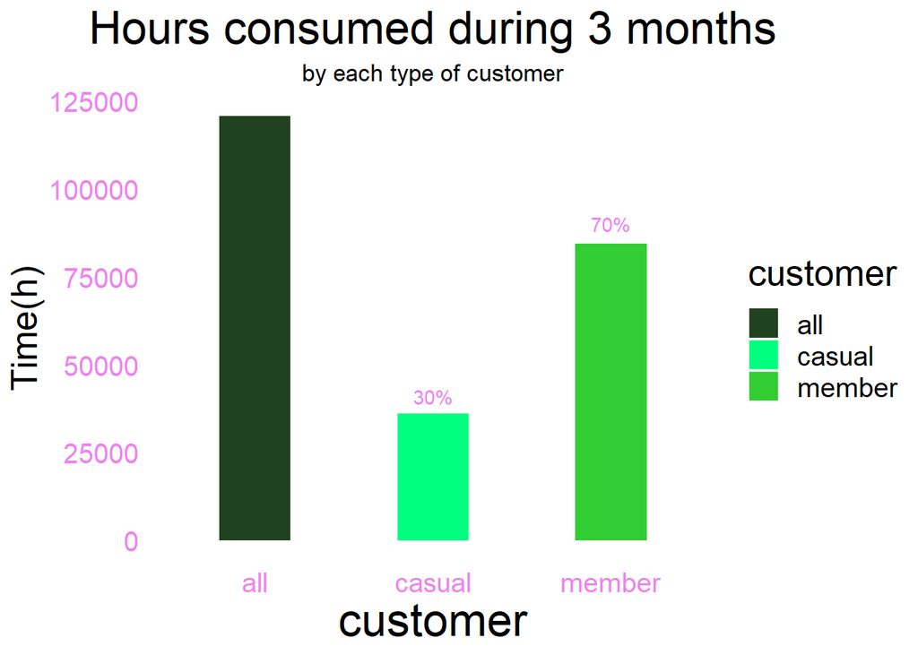

[figure not shown]

```r
#creating data frame :

minutes <- 60

duration_customers <- data.frame(customer = c("all", "casual", "member"),
                            duration_h = c(all_duration/minutes, casual_duration1/minutes, member_duration2/minutes)
                           )

all_hours <- all_duration/minutes

# Percentage of duration
duration_customers <- duration_customers %>%
  group_by(customer) %>%
  mutate(perc_duration =round(duration_h/all_hours * multiply_by_ahundred))

#Duration of trips made by each type of customer over 3 months
barchart_duration <- ggplot(duration_customers,
                            aes(x = customer, y = duration_h,
                                                fill = customer))+
    geom_bar(stat = "identity", width = 0.4 )+
    scale_fill_manual(values = c("#21421e","#00ff7f","#32cd32")
                      )

barchart_duration+
 labs(title = "Hours consumed during 3 months",
         subtitle = "by each type of customer",
      y = "Time(h)")+
    theme(plot.title = element_text(hjust = 0.5, size = 25),
          plot.subtitle = element_text(hjust = 0.5, size = 13),
          panel.background = element_blank(),
          axis.title.y = element_text(size = 20),
          axis.text.y= element_text(size = 15, color = "violet"),
          axis.ticks.y= element_blank(),
          axis.text.x = element_text(size = 15, color = "violet"),
          axis.ticks.x = element_blank(),
          axis.title.x = element_text(size = 25),
          legend.title = element_text(size = 20),
          legend.text = element_text(size = 15))+
    annotate("text",x= "casual", y=41000, label = "30%", fontface = "plain", color = "violet")+
    annotate("text", x ="member", y = 90000, label = "70%", fontface = "plain", color = "violet")
```

**Bike Demand by hour**

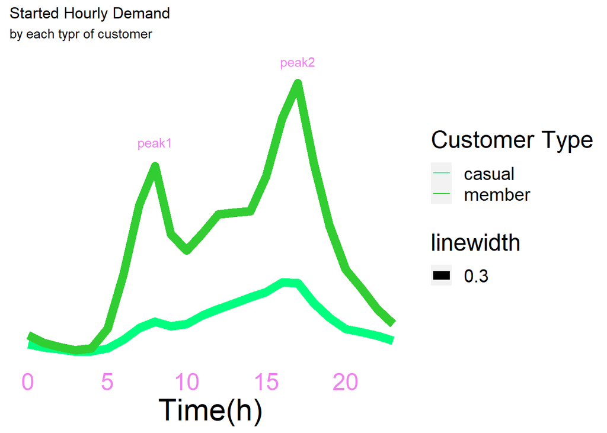

```r
#create column for start hour
bike_share1$start_hour <- hour(bike_share1$started_at)

# create start hour dataframe
start <- bike_share1 %>%
    select(member_casual, start_hour) %>%
    group_by(member_casual) %>%
    count(start_hour)

# rename column
start <- start %>%
    rename( frequent_h = n)

#VIZ
features_line <- theme(panel.background = element_blank(),
          axis.title.y = element_blank(),
          axis.text.y = element_blank(),
          axis.ticks.y = element_blank(),
          axis.title.x = element_text(size = 25),
          axis.text.x = element_text(size = 20, color = "violet"),
          axis.ticks.x = element_blank(),
          legend.title = element_text(size = 20),
          legend.text = element_text(size = 15))

annotate1_line <- annotate("text",x= 8, y=42000, label = "peak1", fontface = "plain", color = "violet")

annotate2_line <- annotate("text", x =17, y = 58000, label = "peak2", fontface = "plain", color = "violet")

#VIZ
start_time <- ggplot(start, aes(x = start_hour, y = frequent_h)) +
               geom_line(aes
                         (color = member_casual, linewidth = 0.3))+
               scale_color_manual(values = c("#00ff7f", "#32cd32"),
                                  name = "Customer Type")
start_time+
    labs(title = "Started Hourly Demand",
         subtitle = "by each typr of customer", x = "Time(h)")+
    features_line+
    annotate1_line+
    annotate2_line
```

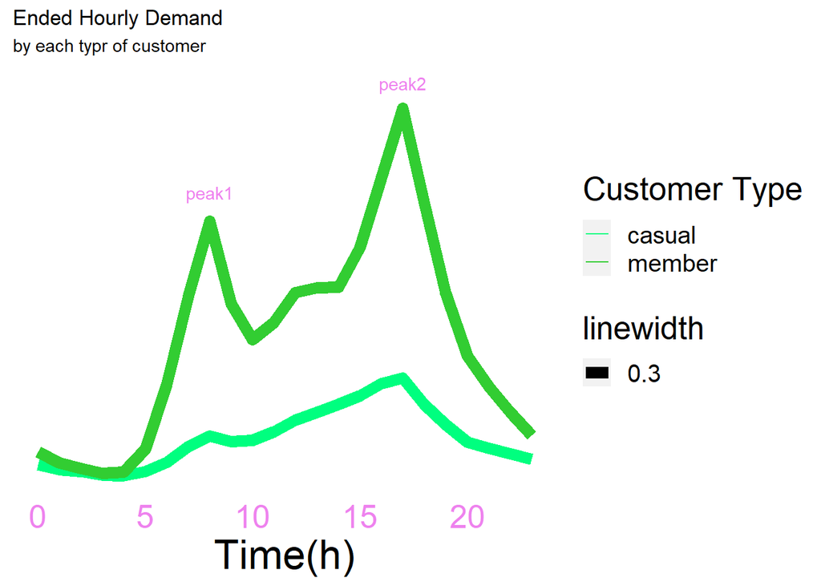

```r
#create column for end hour
bike_share1$ended_hour <- hour(bike_share1$ended_at)

#create end hour dataframe
end <- bike_share1 %>%
    select(member_casual, ended_hour) %>%
    group_by(member_casual) %>%
    count(ended_hour)

#rename column
end <- end %>%
    rename(frequent_h = n)

#VIZ
end_time <- ggplot(end, aes(x = ended_hour, y = frequent_h))+
               geom_line(aes(color = member_casual,
                             linewidth = 0.3))+
               scale_color_manual(values = c("#00ff7f", "#32cd32"),
                                  name = "Customer Type")
end_time+
    labs(title = "Ended Hourly Demand",
         subtitle = "by each typr of customer", x = "Time(h)")+
    features_line+
    annotate1_line+
    annotate2_line
```

*Bike demand by days of week*

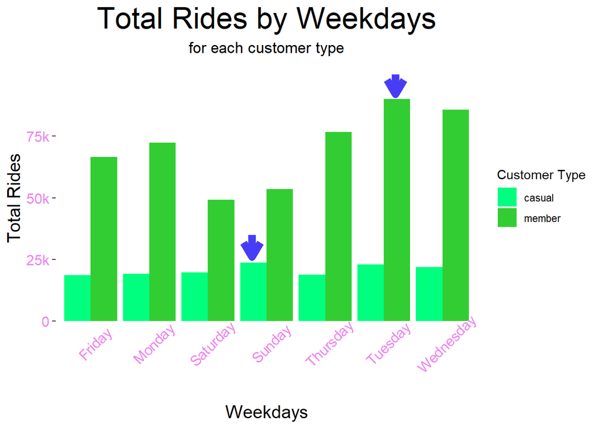

```r
# create column for start days
bike_share1$start_day <- weekdays(bike_share1$started_at)

#VIZ:
# y axis ticks , theme annotate for start and end day:
y_axis_lebal <- scale_y_continuous( breaks= c(0, 25000, 50000, 75000),
                                labels=c("0","25k","50k","75k")
                                   )

features_barchart <- theme(panel.background = element_blank(),
          axis.title.x = element_text(size = 15),
          axis.ticks.x = element_blank(),
          axis.text.x = element_text(size = 12,
                                     color = "violet", angle = 45),
          axis.title.y = element_text(size = 15),
          axis.text.y = element_text(size = 12, color = "violet"),
          plot.title = element_text(hjust = 0.5, size = 25),
          plot.subtitle = element_text(hjust = 0.5, size = 13)
                          )

annotate1_barchart <- annotate("segment", x = 3.75, xend = 3.75, y = 35000,
             yend = 26000, colour = "#483df6", linewidth=3,
             arrow=arrow(length = unit(0.5, "cm")
                         )
                               )

annotate2_barchart <- annotate("segment", x = 6.2, xend = 6.2, y = 100000,
             yend = 92000, colour = "#483df6", linewidth=3,
             arrow = arrow(length = unit(0.5, "cm")
                           )
                               )

# VIZ start day:
day_start <- ggplot(bike_share1)+
               geom_bar(aes(x = start_day,
                              fill = member_casual),
                                   position = "dodge")+
               scale_fill_manual(values = c("#00ff7f", "#32cd32"),
                                 name = "Customer Type")
day_start +
    labs(title = "Total Rides by Weekdays",
         subtitle = "for each customer type",
         x = "Weekdays", y ="Total Rides")+
   y_axis_lebal +
   features_barchart+
   annotate1_barchart+
   annotate2_barchart
```

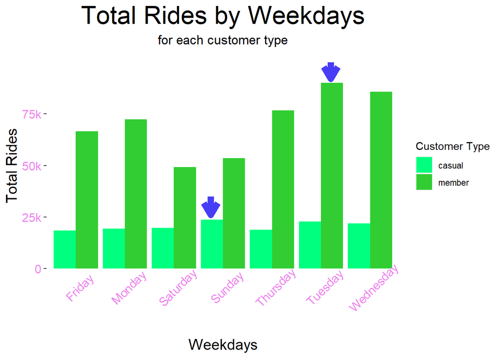

```r
# create column for end days
bike_share1$end_day <- weekdays(bike_share1$ended_at)

#VIZ end day:
day_end <- ggplot(bike_share1)+
             geom_bar(aes(x = end_day,fill = member_casual),
                      position = "dodge")+
             scale_fill_manual(values = c("#00ff7f", "#32cd32"),
                               name = "Customer Type")
day_end +
    labs(title = "Total Rides by Weekdays",
         subtitle = "for each customer type",
         x = "Weekdays", y ="Total Rides")+
    y_axis_lebal+
    features_barchart+
    annotate1_barchart+
    annotate2_barchart
```

**Most popular street for both type:**

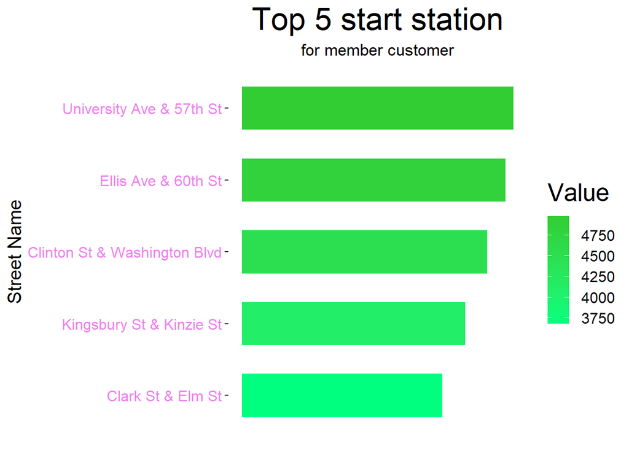

```r
# create a dataframe for start station:
common_start_street <- bike_share1 %>%
    select(member_casual, start_station_name) %>%
    group_by(member_casual) %>%
    count(start_station_name)

# rename column
common_start_street <- common_start_street %>%
                            rename(frequent_street = n)

# member datafraem
common_street_member1 <- common_start_street %>%
    filter(member_casual == "member") %>%
    arrange(desc(frequent_street)) %>%
    group_by(member_casual) %>%
    slice(1:5)

# casual dataframe
common_street_casual1 <- common_start_street %>%
    filter(member_casual == "casual") %>%
    arrange(desc(frequent_street)) %>%
    group_by(member_casual) %>%
    slice(1:5)

# VIZ
# color & features plot for both :
color_chart <- scale_fill_gradient(low = "#00ff7f", high = "#32cd32",
                        name = "Value")

features_chart <- theme(panel.background = element_blank(),
          plot.title = element_text(hjust = 0.5, size = 25),
          plot.subtitle = element_text(hjust = 0.5, size = 13),
          axis.title.x = element_blank(),
          axis.text.x = element_blank(),
          axis.ticks.x = element_blank(),
          axis.title.y = element_text(size = 15),
          axis.text.y = element_text(size = 12, color = "violet"),
          legend.title = element_text(size = 20),
          legend.text = element_text(size = 12)
                        )

# VIZ member
street_member <- ggplot(common_street_member1,
                        aes(x = reorder(start_station_name,
                                        + frequent_street),
                                  y = frequent_street,
                    fill = common_street_member1$frequent_street)
                        )+
                       geom_bar(stat = "identity", width = 0.6)+
                       coord_flip()

street_member+
    labs(title = "Top 5 start station",
         subtitle = "for member customer",
         x = "Street Name")+
    color_chart+
    features_chart
```

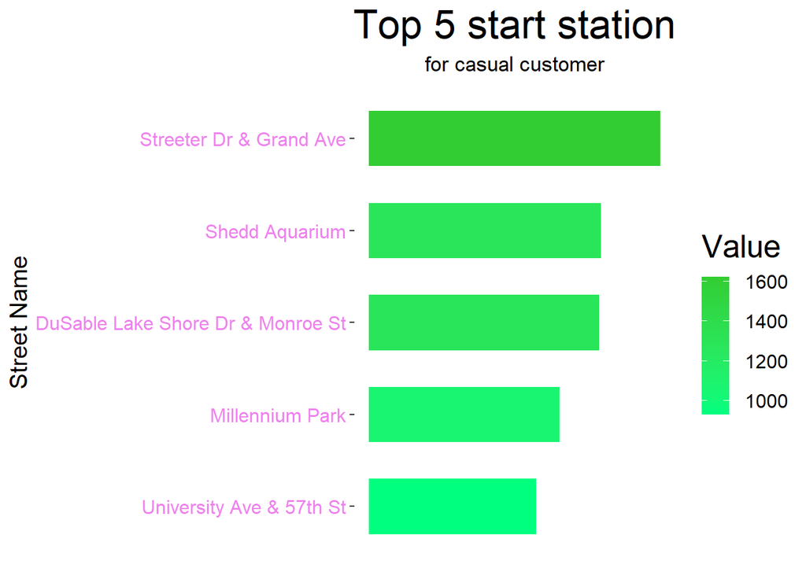

```r
# VIZ casual
street_casual <- ggplot(common_street_casual1,
                        aes(x = reorder(start_station_name,
                                        + frequent_street),
                            y = frequent_street,
              fill = common_street_casual1$frequent_street)
              ) +
    geom_bar(stat = "identity", width = 0.6)+
    coord_flip()

street_casual+
    labs(title = "Top 5 start station",
         subtitle = "for casual customer",
         x = "Street Name")+
   color_chart+
   features_chart
```

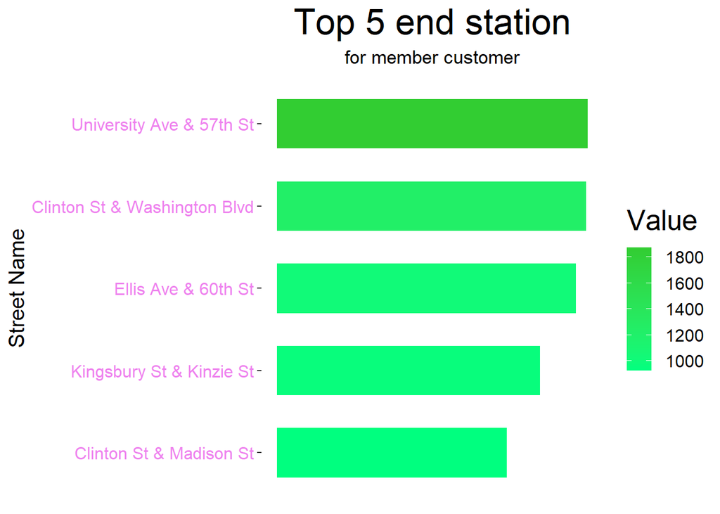

```r
# create a dataframe for end station:
common_end_street <- bike_share1 %>%
    select(member_casual, end_station_name) %>%
    group_by(member_casual) %>%
    count(end_station_name)

# rename column
common_end_street <- common_end_street %>%
                            rename(frequent_street = n)

# member dataframe
common_end_member1 <- common_end_street %>%
    filter(member_casual == "member") %>%
    arrange(desc(frequent_street)) %>%
    group_by(member_casual) %>%
    slice(1:5)

# casual dataframe
common_end_casual1 <- common_end_street %>%
    filter(member_casual == "casual") %>%
    arrange(desc(frequent_street)) %>%
    group_by(member_casual) %>%
    slice(1:5)

# VIZ member
street_member1 <- ggplot(common_end_member1,
                         aes(x = reorder(end_station_name,
                                         + frequent_street),
                             y = frequent_street,
                        fill = common_end_casual1$frequent_street)
                         )+
    geom_bar(stat = "identity", width = 0.6)+
    coord_flip()

street_member1 +
    labs(title = "Top 5 end station",
         subtitle = "for member customer",
         x = "Street Name")+
    color_chart+
    features_chart
```

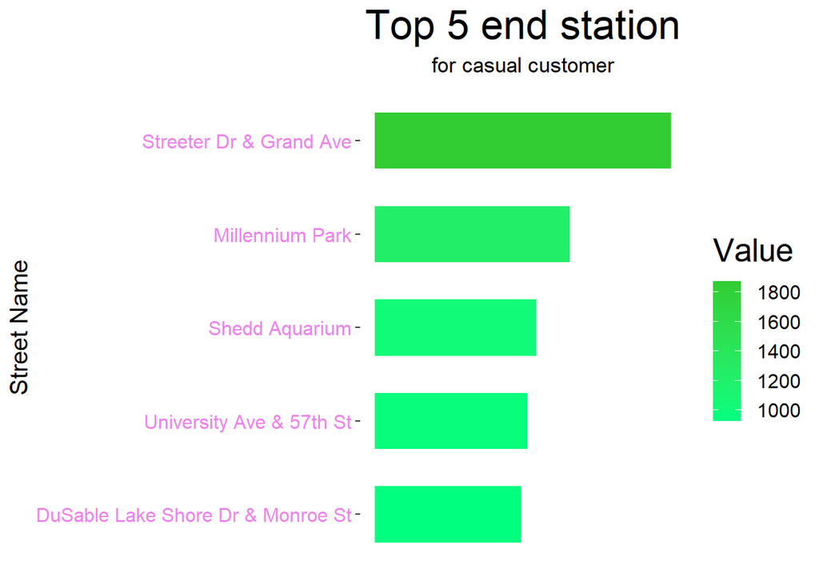

```r
# VIZ casual
street_casual1 <- ggplot(common_end_casual1,
                         aes(x = reorder(end_station_name,
                                         + frequent_street),
                             y = frequent_street,
                    fill = common_end_casual1$frequent_street)
                         ) +
    geom_bar(stat = "identity", width = 0.6)+
    coord_flip()

street_casual1 +
    labs(title = "Top 5 end station",
         subtitle = "for casual customer",
         x = "Street Name")+
    color_chart+
    features_chart
```